# Assignment 3 — Part B

Bayesian networks for carrier preference

Kai

This report analyzes 877 observations of preferred carrier (Y) and satisfaction with reputation (X1), price (X2), and service variety (X3). Unless otherwise stated, the global prior precision is $\alpha=12$. All reported accuracies are in-sample. R version: 4.5.1; bnlearn: 5.2.1; gRain: 1.4.6.

Code is retained in the document and can be expanded using the **Code** buttons.

## B1. Data exploration

### Read and recode the data

```r
raw <- read.csv("data/carrier_data.csv")

d <- raw

d$Y <- factor(
  raw$Y,
  levels = c(1, 2, 3),
  labels = c("A", "B", "C")
)

d$X1 <- factor(
  raw$X1,
  levels = c(0, 1),
  labels = c("low", "high")
)

d$X2 <- factor(
  raw$X2,
  levels = c(0, 1),
  labels = c("low", "high")
)
d$X3 <- factor(
  raw$X3,
  levels = c(0, 1),
  labels = c("low", "high")
)

stopifnot(nrow(d) == 877, !anyNA(d))
knitr::kable(head(d), caption = "First six observations after recoding")
```

First six observations after recoding

| X1 | X2 | X3 | Y |
| --- | --- | --- | --- |
| low | low | low | A |
| low | low | low | A |
| low | low | low | A |
| low | low | low | A |
| low | low | low | A |
| low | low | low | A |

The four variables are factors because their values represent categories. For Y, the original codes 1, 2, and 3 map to A, B, and C; for each attribute, 0 and 1 map to low and high. We retain `raw` for checking the original coding.

### Four-way contingency table

```r
four_way <- xtabs(~ Y + X1 + X2 + X3, data = d)
compact_counts <- ftable(four_way, row.vars = c("X1", "X2", "X3"), col.vars = "Y")
compact_counts
```

```
##                Y   A   B   C
## X1   X2   X3
## low  low  low    113  98  73
##           high    35  18  17
##      high low     19   8   7
##           high    36   9  15
## high low  low     21  60   5
##           high    27  66   9
##      high low      8   8   6
##           high    74 113  32
```

```r
stopifnot(sum(four_way) == nrow(d))
```

### Cross-tabulations of Y with each X

```r
y_x1 <- table(Y = d$Y, X1 = d$X1)
y_x2 <- table(Y = d$Y, X2 = d$X2)
y_x3 <- table(Y = d$Y, X3 = d$X3)

knitr::kable(y_x1, caption = "Y and reputation satisfaction (X1)")
```

Y and reputation satisfaction (X1)

|  | low | high |
| --- | --- | --- |
| A | 203 | 130 |
| B | 133 | 247 |
| C | 112 | 52 |

```r
knitr::kable(y_x2, caption = "Y and price satisfaction (X2)")
```

Y and price satisfaction (X2)

|  | low | high |
| --- | --- | --- |
| A | 196 | 137 |
| B | 242 | 138 |
| C | 104 | 60 |

```r
knitr::kable(y_x3, caption = "Y and service variety satisfaction (X3)")
```

Y and service variety satisfaction (X3)

|  | low | high |
| --- | --- | --- |
| A | 161 | 172 |
| B | 174 | 206 |
| C | 91 | 73 |

### Which attribute appears most related to the preferred provider?

```r
high_proportions <- data.frame(
  Attribute = c("Reputation (X1)", "Price (X2)", "Service variety (X3)"),
  A = c(prop.table(y_x1, 1)["A", "high"], prop.table(y_x2, 1)["A", "high"], prop.table(y_x3, 1)["A", "high"]),
  B = c(prop.table(y_x1, 1)["B", "high"], prop.table(y_x2, 1)["B", "high"], prop.table(y_x3, 1)["B", "high"]),
  C = c(prop.table(y_x1, 1)["C", "high"], prop.table(y_x2, 1)["C", "high"], prop.table(y_x3, 1)["C", "high"])
)
knitr::kable(high_proportions, digits = 4,
             caption = "Proportion reporting high satisfaction within each provider group")
```

Proportion reporting high satisfaction within each provider group

| Attribute | A | B | C |
| --- | --- | --- | --- |
| Reputation (X1) | 0.3904 | 0.6500 | 0.3171 |
| Price (X2) | 0.4114 | 0.3632 | 0.3659 |
| Service variety (X3) | 0.5165 | 0.5421 | 0.4451 |

Reputation (X1) appears most related to provider preference: the proportions reporting high reputation satisfaction are 39.04% for A, 65.00% for B, and 31.71% for C. The between-group differences are smaller for price and service variety.

#### Supplementary binary logistic regressions

The following exploratory models compare each provider with the other two combined. They supplement the cross-tabulations and do not replace the Bayesian networks. Their separately estimated probabilities need not sum to one.

```r
model_1 <- glm(I(Y == "A") ~ X1 + X2 + X3,
               data = d, family = binomial())

model_2 <- glm(I(Y == "B") ~ X1 + X2 + X3,
               data = d, family = binomial())

model_3 <- glm(I(Y == "C") ~ X1 + X2 + X3,
               data = d, family = binomial())

# Compare coefficients across the three models
round(cbind(
  A = coef(model_1),
  B = coef(model_2),
  C = coef(model_3)
), 3)
```

```
##                  A      B      C
## (Intercept) -0.348 -0.688 -1.149
## X1high      -0.918  1.523 -0.967
## X2high       0.442 -0.654  0.312
## X3high       0.226 -0.201 -0.065
```

## B2. Naive Bayes by hand and in software

### B2.1 Naive Bayes DAG and factorization

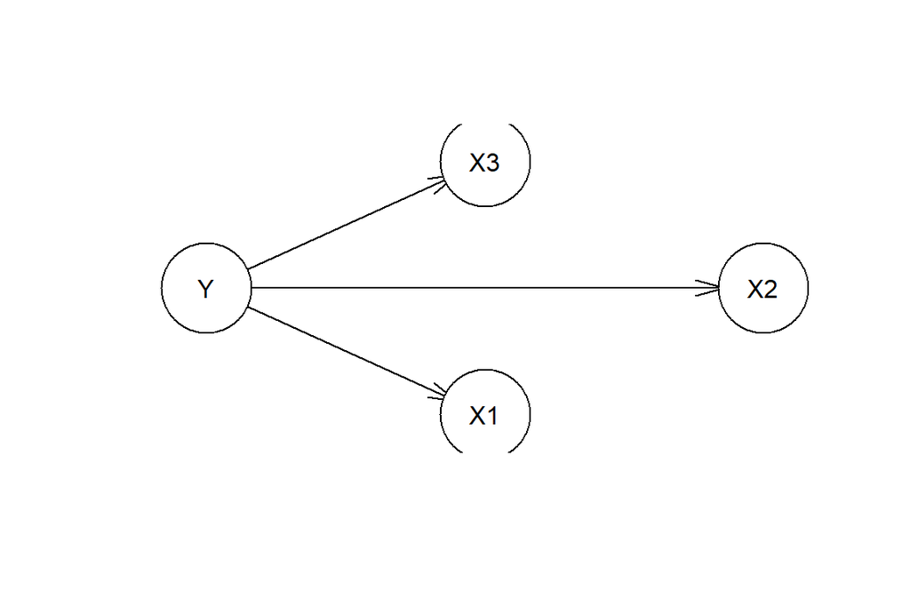

```r
nb <- naive.bayes(d, training = "Y")
plot(nb)
```

The model assumes that X1, X2, and X3 are mutually independent conditional on Y.

The joint distribution factorizes as:

$$p(y,x_1,x_2,x_3)
=
p(y)\,p(x_1\mid y)\,p(x_2\mid y)\,p(x_3\mid y).$$

#### Parameter vectors

Let $(Y_1,Y_2,Y_3,Y_4)=(Y,X_1,X_2,X_3)$. The parameter vectors are

$$\boldsymbol{\theta}_1=(P(Y=A),P(Y=B),P(Y=C)),$$

and, for each $j\in\{A,B,C\}$,

$$\begin{aligned}
\boldsymbol{\theta}_{2j}&=(P(X_1=L\mid Y=j),P(X_1=H\mid Y=j)),\\
\boldsymbol{\theta}_{3j}&=(P(X_2=L\mid Y=j),P(X_2=H\mid Y=j)),\\
\boldsymbol{\theta}_{4j}&=(P(X_3=L\mid Y=j),P(X_3=H\mid Y=j)).
\end{aligned}$$

Here $L=\mathrm{low}$ and $H=\mathrm{high}$.

### B2.2 Dirichlet priors and posteriors

With global precision $\alpha=12$, the prior parameters are

$$\alpha_{ijk}=\frac{\alpha}{C_iQ_i}.$$

For $Y$, we have $C_1=3$ and $Q_1=1$, so

$$\boldsymbol{\theta}_1 \sim \operatorname{Dir}(4,4,4).$$

For each attribute, $C_i=2$ and $Q_i=3$. Therefore, for $j\in\{A,B,C\}$,

$$\boldsymbol{\theta}_{2j},
\boldsymbol{\theta}_{3j},
\boldsymbol{\theta}_{4j}
\sim \operatorname{Dir}(2,2).$$

#### Posterior distributions of all parameters

For each parameter vector, Dirichlet–multinomial conjugacy gives

$$\boldsymbol{\theta}_{ij}\mid D
\sim \operatorname{Dir}
\left(\alpha_{ij1}+N_{ij1},\ldots,
\alpha_{ijC_i}+N_{ijC_i}\right),$$

where $N_{ijk}$ is the observed count for category $k$ under parent configuration $j$. Thus, each posterior parameter is the corresponding prior parameter plus the observed count.

##### Class probabilities

The category order is $(A,B,C)$. The observed class counts are $(333,380,164)$. With prior $\operatorname{Dir}(4,4,4)$,

$$\begin{aligned}
\boldsymbol{\theta}_1\mid D
&\sim \operatorname{Dir}(4+333,\;4+380,\;4+164)\\
&=\operatorname{Dir}(337,\;384,\;168).
\end{aligned}$$

##### Reputation satisfaction: $X_1$

For each provider, the category order is $(\mathrm{low},\mathrm{high})$ and the prior is $\operatorname{Dir}(2,2)$. The observed counts for providers A, B, and C are $(203,130)$, $(133,247)$, and $(112,52)$, respectively.

$$\begin{aligned}
\boldsymbol{\theta}_{2A}\mid D
&\sim \operatorname{Dir}(2+203,\;2+130)
= \operatorname{Dir}(205,\;132),\\
\boldsymbol{\theta}_{2B}\mid D
&\sim \operatorname{Dir}(2+133,\;2+247)
= \operatorname{Dir}(135,\;249),\\
\boldsymbol{\theta}_{2C}\mid D
&\sim \operatorname{Dir}(2+112,\;2+52)
= \operatorname{Dir}(114,\;54).
\end{aligned}$$

##### Price satisfaction: $X_2$

The category order is $(\mathrm{low},\mathrm{high})$. The observed counts for providers A, B, and C are $(196,137)$, $(242,138)$, and $(104,60)$, respectively. Adding the prior parameters $(2,2)$ gives

$$\begin{aligned}
\boldsymbol{\theta}_{3A}\mid D
&\sim \operatorname{Dir}(2+196,\;2+137)
= \operatorname{Dir}(198,\;139),\\
\boldsymbol{\theta}_{3B}\mid D
&\sim \operatorname{Dir}(2+242,\;2+138)
= \operatorname{Dir}(244,\;140),\\
\boldsymbol{\theta}_{3C}\mid D
&\sim \operatorname{Dir}(2+104,\;2+60)
= \operatorname{Dir}(106,\;62).
\end{aligned}$$

##### Service variety satisfaction: $X_3$

The category order is $(\mathrm{low},\mathrm{high})$. The observed counts for providers A, B, and C are $(161,172)$, $(174,206)$, and $(91,73)$, respectively. Adding the prior parameters $(2,2)$ gives

$$\begin{aligned}
\boldsymbol{\theta}_{4A}\mid D
&\sim \operatorname{Dir}(2+161,\;2+172)
= \operatorname{Dir}(163,\;174),\\
\boldsymbol{\theta}_{4B}\mid D
&\sim \operatorname{Dir}(2+174,\;2+206)
= \operatorname{Dir}(176,\;208),\\
\boldsymbol{\theta}_{4C}\mid D
&\sim \operatorname{Dir}(2+91,\;2+73)
= \operatorname{Dir}(93,\;75).
\end{aligned}$$

Under the assumed independent Dirichlet priors and the naive Bayes likelihood, these ten parameter vectors remain mutually independent in the posterior.

### B2.3 Posterior classification probabilities by hand

For a customer with $X_1=\mathrm{high}$, $X_2=\mathrm{low}$, and $X_3=\mathrm{high}$, we want to calculate

$$P(Y=j\mid X_1=\mathrm{high},X_2=\mathrm{low},
X_3=\mathrm{high},D),
\qquad j\in\{A,B,C\}.$$

Under naive Bayes, the unnormalized weight for class $j$ is

$$w_j =
P(Y=j\mid D)
P(X_1=\mathrm{high}\mid Y=j,D)
P(X_2=\mathrm{low}\mid Y=j,D)
P(X_3=\mathrm{high}\mid Y=j,D).$$

Each probability is obtained from the corresponding Dirichlet posterior mean: divide its category parameter by the sum of the parameters in that vector.

#### Step 1: Obtain the required posterior means

For the class probabilities, the posterior is $\operatorname{Dir}(337,384,168)$, with total $889$.

For the attributes, use the high component for $X_1$ and $X_3$, and the low component for $X_2$.

| Class | $P(Y=j\mid D)$ | $P(X_1=\mathrm{high}\mid j,D)$ | $P(X_2=\mathrm{low}\mid j,D)$ | $P(X_3=\mathrm{high}\mid j,D)$ |
| --- | --- | --- | --- | --- |
| A | $337/889$ | $132/337$ | $198/337$ | $174/337$ |
| B | $384/889$ | $249/384$ | $244/384$ | $208/384$ |
| C | $168/889$ | $54/168$ | $106/168$ | $75/168$ |

For example, the posterior for $X_1$ given $Y=A$ is $\operatorname{Dir}(205,132)$, so

$$P(X_1=\mathrm{high}\mid Y=A,D)
=\frac{132}{205+132}
=\frac{132}{337}.$$

#### Step 2: Calculate the unnormalized class weights

$$\begin{aligned}
w_A
&=\frac{337}{889}
\frac{132}{337}
\frac{198}{337}
\frac{174}{337},\\[4pt]
w_B
&=\frac{384}{889}
\frac{249}{384}
\frac{244}{384}
\frac{208}{384},\\[4pt]
w_C
&=\frac{168}{889}
\frac{54}{168}
\frac{106}{168}
\frac{75}{168}.
\end{aligned}$$

#### Step 3: Normalize the weights

The weights are joint predictive probabilities. To obtain conditional class probabilities, divide each by their sum:

$$P(Y=j\mid x,D)=\frac{w_j}{w_A+w_B+w_C}.$$

This gives

$$\begin{aligned}
P(Y=A\mid x,D)&\approx 0.284084,\\
P(Y=B\mid x,D)&\approx 0.608006,\\
P(Y=C\mid x,D)&\approx 0.107910.
\end{aligned}$$

The three probabilities sum to 1. We classify this customer as preferring **provider B**, which has the highest posterior classification probability, approximately **60.80%**.

```r
hand_weights <- c(
  A = (337/889) * (132/337) * (198/337) * (174/337),
  B = (384/889) * (249/384) * (244/384) * (208/384),
  C = (168/889) * (54/168) * (106/168) * (75/168)
)
hand_probs <- hand_weights / sum(hand_weights)
knitr::kable(data.frame(Provider = names(hand_probs),
                         Weight = as.numeric(hand_weights),
                         Probability = as.numeric(hand_probs)), digits = 6)
```

| Provider | Weight | Probability |
| --- | --- | --- |
| A | 0.045043 | 0.284084 |
| B | 0.096403 | 0.608006 |
| C | 0.017110 | 0.107910 |

### B2.4 Verification using bnlearn

#### Fit the naive Bayes model

```r
nb <- naive.bayes(d, training = "Y")

nb_fit <- bn.fit(
  nb,
  data = d,
  method = "bayes",
  iss = 12
)

# Conditional probability tables: posterior means
coef(nb_fit)
```

```
## $Y
##         A         B         C
## 0.3790776 0.4319460 0.1889764
##
## $X1
##       Y
## X1             A         B         C
##   low  0.6083086 0.3515625 0.6785714
##   high 0.3916914 0.6484375 0.3214286
##
## $X2
##       Y
## X2             A         B         C
##   low  0.5875371 0.6354167 0.6309524
##   high 0.4124629 0.3645833 0.3690476
##
## $X3
##       Y
## X3             A         B         C
##   low  0.4836795 0.4583333 0.5535714
##   high 0.5163205 0.5416667 0.4464286
```

The argument `iss = 12` corresponds to the global precision $\alpha=12$. The fitted probability tables contain posterior means, rather than the full Dirichlet posterior distributions.

#### Verify the posterior Dirichlet parameters

For Y, each prior parameter is $12/(3\times1)=4$. For each attribute conditional on Y, each prior parameter is $12/(2\times3)=2$. Adding the observed counts gives:

```r
post_Y  <- table(d$Y) + 4
post_X1 <- table(Y = d$Y, X1 = d$X1) + 2
post_X2 <- table(Y = d$Y, X2 = d$X2) + 2
post_X3 <- table(Y = d$Y, X3 = d$X3) + 2

post_Y
```

```
##
##   A   B   C
## 337 384 168
```

```r
post_X1
```

```
##    X1
## Y   low high
##   A 205  132
##   B 135  249
##   C 114   54
```

```r
post_X2
```

```
##    X2
## Y   low high
##   A 198  139
##   B 244  140
##   C 106   62
```

```r
post_X3
```

```
##    X3
## Y   low high
##   A 163  174
##   B 176  208
##   C  93   75
```

For Y, the entries form one Dirichlet parameter vector. For each attribute, each row forms a Dirichlet parameter vector in the order low/high. These reproduce B2.2.

#### Predict the specified customer’s preference

```r
customer <- data.frame(
  X1 = factor("high", levels = levels(d$X1)),
  X2 = factor("low",  levels = levels(d$X2)),
  X3 = factor("high", levels = levels(d$X3))
)

prediction <- predict(
  nb_fit,
  data = customer,
  prob = TRUE
)

prediction
```

```
## [1] B
## attr(,"prob")
##        [,1]
## A 0.2840839
## B 0.6080064
## C 0.1079097
## Levels: A B C
```

```r
software_probs <- attr(prediction, "prob")
round(software_probs, 6)
```

```
##       [,1]
## A 0.284084
## B 0.608006
## C 0.107910
```

```r
stopifnot(max(abs(software_probs[c("A", "B", "C"), 1] - hand_probs)) < 1e-10)
```

The probabilities are approximately 0.284084 for A, 0.608006 for B, and 0.107910 for C, matching the hand calculation in B2.3. The predicted provider is B.

#### Verify using cpquery

```r
set.seed(20261002)

query_probs <- c(
  A = cpquery(
    nb_fit,
    event = (Y == "A"),
    evidence = (X1 == "high" & X2 == "low" & X3 == "high"),
    method = "ls",
    n = 1000000
  ),
  B = cpquery(
    nb_fit,
    event = (Y == "B"),
    evidence = (X1 == "high" & X2 == "low" & X3 == "high"),
    method = "ls",
    n = 1000000
  ),
  C = cpquery(
    nb_fit,
    event = (Y == "C"),
    evidence = (X1 == "high" & X2 == "low" & X3 == "high"),
    method = "ls",
    n = 1000000
  )
)

comparison <- data.frame(
  Provider = c("A", "B", "C"),
  Predict = as.numeric(software_probs[c("A", "B", "C"), 1]),
  Cpquery = as.numeric(query_probs)
)

knitr::kable(comparison, digits = 6)
```

| Provider | Predict | Cpquery |
| --- | --- | --- |
| A | 0.284084 | 0.282934 |
| B | 0.608006 | 0.607798 |
| C | 0.107910 | 0.109086 |

With `method = "ls"`, `cpquery()` simulates observations from the fitted network, retains those matching the evidence, and estimates the fraction belonging to the requested class.

Its results differ slightly from the exact probabilities because of Monte Carlo sampling error. Without resetting the seed, repeated calls generally produce different estimates. Resetting the same seed makes the simulation reproducible; increasing the number of samples generally reduces the error.

Because A, B, and C are estimated in separate simulation calls, their estimated probabilities need not sum to exactly 1.

## B3. Prior sensitivity

We refit the naive Bayes model with $\alpha=1,12,100,1000$ and compare the classification probabilities for the customer with high reputation, low price, and high service satisfaction.

```r
alpha_values <- c(1, 12, 100, 1000)

sensitivity <- data.frame(
  alpha = alpha_values,
  A = NA_real_,
  B = NA_real_,
  C = NA_real_
)

for (i in seq_along(alpha_values)) {
  fit <- bn.fit(
    nb,
    data = d,
    method = "bayes",
    iss = alpha_values[i]
  )

  pred <- predict(fit, data = customer, prob = TRUE)

  sensitivity[i, c("A", "B", "C")] <-
    as.numeric(attr(pred, "prob")[c("A", "B", "C"), 1])
}

knitr::kable(sensitivity, digits = 6)
```

| alpha | A | B | C |
| --- | --- | --- | --- |
| 1 | 0.283427 | 0.611108 | 0.105465 |
| 12 | 0.284084 | 0.608006 | 0.107910 |
| 100 | 0.288833 | 0.585496 | 0.125672 |
| 1000 | 0.311772 | 0.470356 | 0.217872 |

The predicted provider remains **B** for all four prior strengths. However, its classification probability decreases as $\alpha$ increases, while the probabilities of A and C increase.

To explain this, the posterior mean can be written as

$$E(\theta_{ijk}\mid D)
=
\frac{N_{ijk}+\alpha/(C_iQ_i)}
{N_{ij}+\alpha/Q_i}
=
\frac{N_{ij}}{N_{ij}+\alpha/Q_i}
\frac{N_{ijk}}{N_{ij}}
+
\frac{\alpha/Q_i}{N_{ij}+\alpha/Q_i}
\frac{1}{C_i}.$$

Thus, the posterior mean is a weighted average of the observed proportion and the uniform prior mean $1/C_i$.

When $\alpha$ is small, the data receive more weight. As $\alpha$ increases, the uniform prior receives more weight, pulling the conditional probabilities toward uniformity.

With the data held fixed, as $\alpha\to\infty$, the class probabilities approach $1/3$ and each binary attribute’s conditional probabilities approach $1/2$. Consequently, the customer’s classification probabilities also approach $(1/3,1/3,1/3)$.

## B4. Five candidate classifiers

### B4.1 Factorizations and parent configurations

#### Joint factorizations

$$\begin{aligned}
M_1:\quad p(y,x_1,x_2,x_3)
&=p(y)p(x_1\mid y)p(x_2\mid y,x_1)p(x_3\mid y,x_1,x_2),\\
M_2:\quad p(y,x_1,x_2,x_3)
&=p(y)p(x_1\mid y)p(x_2\mid y)p(x_3\mid y),\\
M_3:\quad p(y,x_1,x_2,x_3)
&=p(y)p(x_1\mid y)p(x_2\mid y,x_1)p(x_3\mid y),\\
M_4:\quad p(y,x_1,x_2,x_3)
&=p(y)p(x_1\mid y)p(x_2\mid y)p(x_3\mid y,x_1),\\
M_5:\quad p(y,x_1,x_2,x_3)
&=p(y)p(x_1\mid y)p(x_2\mid y)p(x_3\mid y,x_2).
\end{aligned}$$

#### Parent configurations

Let $L=\mathrm{low}$ and $H=\mathrm{high}$. The parent sets for each model are:

| Model | Parents of Y | Parents of X1 | Parents of X2 | Parents of X3 |
| --- | --- | --- | --- | --- |
| M1 | None | Y | (Y, X1) | (Y, X1, X2) |
| M2 | None | Y | Y | Y |
| M3 | None | Y | (Y, X1) | Y |
| M4 | None | Y | Y | (Y, X1) |
| M5 | None | Y | Y | (Y, X2) |

Each parent set has the following configurations. Tuple entries follow the parent order shown above.

- **No parents:** one empty configuration, so $Q=1$.
- **Y:** $A,B,C$, so $Q=3$.
- **(Y, X1):** $(A,L),(A,H),(B,L),(B,H),(C,L),(C,H)$, so $Q=6$.
- **(Y, X2):** $(A,L),(A,H),(B,L),(B,H),(C,L),(C,H)$, so $Q=6$.
- **(Y, X1, X2):** the following twelve configurations, so $Q=12$:

$$\begin{aligned}
&(A,L,L),\ (A,L,H),\ (A,H,L),\ (A,H,H),\\
&(B,L,L),\ (B,L,H),\ (B,H,L),\ (B,H,H),\\
&(C,L,L),\ (C,L,H),\ (C,H,L),\ (C,H,H).
\end{aligned}$$

### B4.2 Estimation and posterior classification probabilities

#### B4.2(a) Parameter estimation and Dirichlet posteriors

##### Define and fit the five models

```r
M1 <- model2network("[Y][X1|Y][X2|Y:X1][X3|Y:X1:X2]")
M2 <- model2network("[Y][X1|Y][X2|Y][X3|Y]")
M3 <- model2network("[Y][X1|Y][X2|Y:X1][X3|Y]")
M4 <- model2network("[Y][X1|Y][X2|Y][X3|Y:X1]")
M5 <- model2network("[Y][X1|Y][X2|Y][X3|Y:X2]")

fit1 <- bn.fit(M1, data = d, method = "bayes", iss = 12)
fit2 <- bn.fit(M2, data = d, method = "bayes", iss = 12)
fit3 <- bn.fit(M3, data = d, method = "bayes", iss = 12)
fit4 <- bn.fit(M4, data = d, method = "bayes", iss = 12)
fit5 <- bn.fit(M5, data = d, method = "bayes", iss = 12)
```

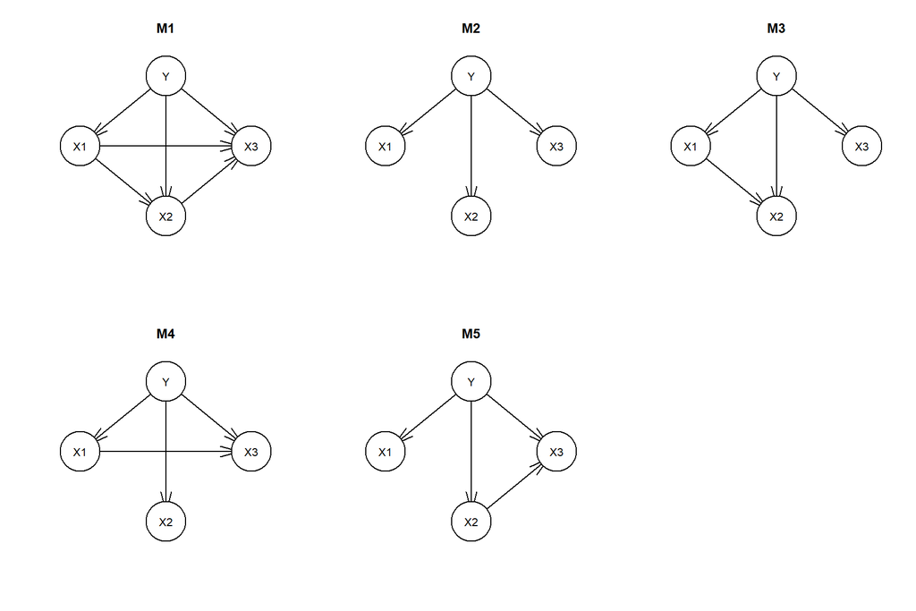

```r
par(mfrow = c(2, 3))

plot(M1, main = "M1")
plot(M2, main = "M2")
plot(M3, main = "M3")
plot(M4, main = "M4")
plot(M5, main = "M5")

par(mfrow = c(1, 1))
```

We report the complete Dirichlet posterior distributions for M3, whose factorization is

$$p(y,x_1,x_2,x_3)
=
p(y)p(x_1\mid y)p(x_2\mid y,x_1)p(x_3\mid y).$$

With $\alpha=12$, the prior parameters are

$$\alpha_{ijk}=\frac{12}{C_iQ_i}.$$

Therefore:

- Y has prior Dir(4,4,4).
- Each X1 given Y vector has prior Dir(2,2).
- Each X2 given (Y,X1) vector has prior Dir(1,1).
- Each X3 given Y vector has prior Dir(2,2).

The posterior parameters equal the prior parameters plus the corresponding observed counts.

##### Class probabilities: Y

The category order is A, B, C.

$$\boldsymbol{\theta}_1\mid D
\sim \operatorname{Dir}(4+333,\;4+380,\;4+164)
=\operatorname{Dir}(337,\;384,\;168).$$

##### X1 conditional on Y

Each vector is ordered low, high.

$$\begin{aligned}
\boldsymbol{\theta}_{2,A}\mid D
&\sim \operatorname{Dir}(2+203,\;2+130)
=\operatorname{Dir}(205,\;132),\\
\boldsymbol{\theta}_{2,B}\mid D
&\sim \operatorname{Dir}(2+133,\;2+247)
=\operatorname{Dir}(135,\;249),\\
\boldsymbol{\theta}_{2,C}\mid D
&\sim \operatorname{Dir}(2+112,\;2+52)
=\operatorname{Dir}(114,\;54).
\end{aligned}$$

##### X2 conditional on Y and X1

There are six parent configurations, so each prior parameter is $12/(2\times6)=1$.

In the subscripts below, $(A,L)$ means $Y=A$ and $X_1=\mathrm{low}$. Each parameter vector describes the probabilities of X2 in the order low, high.

$$\begin{aligned}
\boldsymbol{\theta}_{3,(A,L)}\mid D
&\sim \operatorname{Dir}(1+148,\;1+55)
=\operatorname{Dir}(149,\;56),\\
\boldsymbol{\theta}_{3,(A,H)}\mid D
&\sim \operatorname{Dir}(1+48,\;1+82)
=\operatorname{Dir}(49,\;83),\\
\boldsymbol{\theta}_{3,(B,L)}\mid D
&\sim \operatorname{Dir}(1+116,\;1+17)
=\operatorname{Dir}(117,\;18),\\
\boldsymbol{\theta}_{3,(B,H)}\mid D
&\sim \operatorname{Dir}(1+126,\;1+121)
=\operatorname{Dir}(127,\;122),\\
\boldsymbol{\theta}_{3,(C,L)}\mid D
&\sim \operatorname{Dir}(1+90,\;1+22)
=\operatorname{Dir}(91,\;23),\\
\boldsymbol{\theta}_{3,(C,H)}\mid D
&\sim \operatorname{Dir}(1+14,\;1+38)
=\operatorname{Dir}(15,\;39).
\end{aligned}$$

##### X3 conditional on Y

Each vector is ordered low, high.

$$\begin{aligned}
\boldsymbol{\theta}_{4,A}\mid D
&\sim \operatorname{Dir}(2+161,\;2+172)
=\operatorname{Dir}(163,\;174),\\
\boldsymbol{\theta}_{4,B}\mid D
&\sim \operatorname{Dir}(2+174,\;2+206)
=\operatorname{Dir}(176,\;208),\\
\boldsymbol{\theta}_{4,C}\mid D
&\sim \operatorname{Dir}(2+91,\;2+73)
=\operatorname{Dir}(93,\;75).
\end{aligned}$$

These are all 13 parameter vectors for M3: one for Y, three for X1, six for X2, and three for X3.

#### B4.2(b) Prediction methods and classification probabilities

##### Create the eight profiles

Writing them explicitly makes their order easy to follow:

```r
profiles <- data.frame(
  X1 = c("low", "low", "low", "low",
         "high", "high", "high", "high"),

  X2 = c("low", "low", "high", "high",
         "low", "low", "high", "high"),

  X3 = c("low", "high", "low", "high",
         "low", "high", "low", "high")
)

profiles$X1 <- factor(profiles$X1, levels = levels(d$X1))
profiles$X2 <- factor(profiles$X2, levels = levels(d$X2))
profiles$X3 <- factor(profiles$X3, levels = levels(d$X3))

knitr::kable(profiles)
```

| X1 | X2 | X3 |
| --- | --- | --- |
| low | low | low |
| low | low | high |
| low | high | low |
| low | high | high |
| high | low | low |
| high | low | high |
| high | high | low |
| high | high | high |

##### Compare the three prediction methods

We compare all three methods for each model and all eight profiles. The helper function returns one row per method and profile; likelihood weighting uses 100,000 samples and a fixed seed.

```r
compare_methods <- function(fitted_model) {

  pred_parents <- predict(
    fitted_model, node = "Y", data = profiles,
    method = "parents", prob = TRUE
  )

  set.seed(20261002)
  pred_lw <- predict(
    fitted_model, node = "Y", data = profiles,
    method = "bayes-lw", prob = TRUE, n = 100000
  )

  pred_exact <- predict(
    fitted_model, node = "Y", data = profiles,
    method = "exact", prob = TRUE
  )

  # Probability matrices have classes in rows.
  # t() transposes them so each customer profile becomes a row.
  p_parents <- t(attr(pred_parents, "prob")[c("A", "B", "C"), ])
  p_lw <- t(attr(pred_lw, "prob")[c("A", "B", "C"), ])
  p_exact <- t(attr(pred_exact, "prob")[c("A", "B", "C"), ])

  result <- rbind(
    data.frame(Method = "parents", profiles, p_parents),
    data.frame(Method = "bayes-lw", profiles, p_lw),
    data.frame(Method = "exact", profiles, p_exact)
  )

  return(result)
}

methods1 <- compare_methods(fit1)
methods2 <- compare_methods(fit2)
methods3 <- compare_methods(fit3)
methods4 <- compare_methods(fit4)
methods5 <- compare_methods(fit5)

knitr::kable(methods1, digits = 4, caption = "M1")
```

M1

| Method | X1 | X2 | X3 | A | B | C |
| --- | --- | --- | --- | --- | --- | --- |
| parents | low | low | low | 0.3791 | 0.4319 | 0.1890 |
| parents | low | low | high | 0.3791 | 0.4319 | 0.1890 |
| parents | low | high | low | 0.3791 | 0.4319 | 0.1890 |
| parents | low | high | high | 0.3791 | 0.4319 | 0.1890 |
| parents | high | low | low | 0.3791 | 0.4319 | 0.1890 |
| parents | high | low | high | 0.3791 | 0.4319 | 0.1890 |
| parents | high | high | low | 0.3791 | 0.4319 | 0.1890 |
| parents | high | high | high | 0.3791 | 0.4319 | 0.1890 |
| bayes-lw | low | low | low | 0.3954 | 0.3484 | 0.2563 |
| bayes-lw | low | low | high | 0.5003 | 0.2571 | 0.2427 |
| bayes-lw | low | high | low | 0.5493 | 0.2392 | 0.2115 |
| bayes-lw | low | high | high | 0.5920 | 0.1546 | 0.2534 |
| bayes-lw | high | low | low | 0.2447 | 0.6921 | 0.0632 |
| bayes-lw | high | low | high | 0.2664 | 0.6420 | 0.0915 |
| bayes-lw | high | high | low | 0.3618 | 0.3591 | 0.2791 |
| bayes-lw | high | high | high | 0.3389 | 0.5131 | 0.1480 |
| exact | low | low | low | 0.3975 | 0.3450 | 0.2574 |
| exact | low | low | high | 0.4965 | 0.2587 | 0.2448 |
| exact | low | high | low | 0.5493 | 0.2394 | 0.2113 |
| exact | low | high | high | 0.5935 | 0.1545 | 0.2520 |
| exact | high | low | low | 0.2457 | 0.6914 | 0.0629 |
| exact | high | low | high | 0.2657 | 0.6425 | 0.0918 |
| exact | high | high | low | 0.3617 | 0.3617 | 0.2766 |
| exact | high | high | high | 0.3379 | 0.5147 | 0.1474 |

```r
knitr::kable(methods2, digits = 4, caption = "M2")
```

M2

| Method | X1 | X2 | X3 | A | B | C |
| --- | --- | --- | --- | --- | --- | --- |
| parents | low | low | low | 0.3791 | 0.4319 | 0.1890 |
| parents | low | low | high | 0.3791 | 0.4319 | 0.1890 |
| parents | low | high | low | 0.3791 | 0.4319 | 0.1890 |
| parents | low | high | high | 0.3791 | 0.4319 | 0.1890 |
| parents | high | low | low | 0.3791 | 0.4319 | 0.1890 |
| parents | high | low | high | 0.3791 | 0.4319 | 0.1890 |
| parents | high | high | low | 0.3791 | 0.4319 | 0.1890 |
| parents | high | high | high | 0.3791 | 0.4319 | 0.1890 |
| bayes-lw | low | low | low | 0.4221 | 0.2892 | 0.2887 |
| bayes-lw | low | low | high | 0.4455 | 0.3282 | 0.2264 |
| bayes-lw | low | high | low | 0.4714 | 0.2598 | 0.2688 |
| bayes-lw | low | high | high | 0.4886 | 0.2994 | 0.2119 |
| bayes-lw | high | low | low | 0.2899 | 0.5631 | 0.1470 |
| bayes-lw | high | low | high | 0.2848 | 0.6075 | 0.1076 |
| bayes-lw | high | high | low | 0.3343 | 0.5244 | 0.1413 |
| bayes-lw | high | high | high | 0.3274 | 0.5690 | 0.1037 |
| exact | low | low | low | 0.4240 | 0.2862 | 0.2898 |
| exact | low | low | high | 0.4418 | 0.3301 | 0.2281 |
| exact | low | high | low | 0.4715 | 0.2601 | 0.2685 |
| exact | low | high | high | 0.4900 | 0.2992 | 0.2108 |
| exact | high | low | low | 0.2910 | 0.5626 | 0.1463 |
| exact | high | low | high | 0.2841 | 0.6080 | 0.1079 |
| exact | high | high | low | 0.3335 | 0.5269 | 0.1397 |
| exact | high | high | high | 0.3262 | 0.5706 | 0.1032 |

```r
knitr::kable(methods3, digits = 4, caption = "M3")
```

M3

| Method | X1 | X2 | X3 | A | B | C |
| --- | --- | --- | --- | --- | --- | --- |
| parents | low | low | low | 0.3791 | 0.4319 | 0.1890 |
| parents | low | low | high | 0.3791 | 0.4319 | 0.1890 |
| parents | low | high | low | 0.3791 | 0.4319 | 0.1890 |
| parents | low | high | high | 0.3791 | 0.4319 | 0.1890 |
| parents | high | low | low | 0.3791 | 0.4319 | 0.1890 |
| parents | high | low | high | 0.3791 | 0.4319 | 0.1890 |
| parents | high | high | low | 0.3791 | 0.4319 | 0.1890 |
| parents | high | high | high | 0.3791 | 0.4319 | 0.1890 |
| bayes-lw | low | low | low | 0.4073 | 0.3077 | 0.2850 |
| bayes-lw | low | low | high | 0.4288 | 0.3483 | 0.2229 |
| bayes-lw | low | high | low | 0.5634 | 0.1715 | 0.2651 |
| bayes-lw | low | high | high | 0.5895 | 0.1995 | 0.2110 |
| bayes-lw | high | low | low | 0.2617 | 0.6459 | 0.0925 |
| bayes-lw | high | low | high | 0.2517 | 0.6820 | 0.0663 |
| bayes-lw | high | high | low | 0.3419 | 0.4726 | 0.1855 |
| bayes-lw | high | high | high | 0.3403 | 0.5214 | 0.1384 |
| exact | low | low | low | 0.4093 | 0.3046 | 0.2861 |
| exact | low | low | high | 0.4252 | 0.3503 | 0.2245 |
| exact | low | high | low | 0.5635 | 0.1716 | 0.2649 |
| exact | low | high | high | 0.5909 | 0.1993 | 0.2098 |
| exact | high | low | low | 0.2627 | 0.6452 | 0.0920 |
| exact | high | low | high | 0.2510 | 0.6825 | 0.0664 |
| exact | high | high | low | 0.3412 | 0.4753 | 0.1835 |
| exact | high | high | high | 0.3392 | 0.5230 | 0.1378 |

```r
knitr::kable(methods4, digits = 4, caption = "M4")
```

M4

| Method | X1 | X2 | X3 | A | B | C |
| --- | --- | --- | --- | --- | --- | --- |
| parents | low | low | low | 0.3791 | 0.4319 | 0.1890 |
| parents | low | low | high | 0.3791 | 0.4319 | 0.1890 |
| parents | low | high | low | 0.3791 | 0.4319 | 0.1890 |
| parents | low | high | high | 0.3791 | 0.4319 | 0.1890 |
| parents | high | low | low | 0.3791 | 0.4319 | 0.1890 |
| parents | high | low | high | 0.3791 | 0.4319 | 0.1890 |
| parents | high | high | low | 0.3791 | 0.4319 | 0.1890 |
| parents | high | high | high | 0.3791 | 0.4319 | 0.1890 |
| bayes-lw | low | low | low | 0.3940 | 0.3481 | 0.2579 |
| bayes-lw | low | low | high | 0.5266 | 0.2184 | 0.2551 |
| bayes-lw | low | high | low | 0.4432 | 0.3150 | 0.2418 |
| bayes-lw | low | high | high | 0.5687 | 0.1962 | 0.2351 |
| bayes-lw | high | low | low | 0.2542 | 0.6356 | 0.1102 |
| bayes-lw | high | low | high | 0.2992 | 0.5691 | 0.1316 |
| bayes-lw | high | high | low | 0.2959 | 0.5972 | 0.1069 |
| bayes-lw | high | high | high | 0.3426 | 0.5310 | 0.1263 |
| exact | low | low | low | 0.3962 | 0.3447 | 0.2591 |
| exact | low | low | high | 0.5228 | 0.2199 | 0.2573 |
| exact | low | high | low | 0.4433 | 0.3152 | 0.2415 |
| exact | low | high | high | 0.5702 | 0.1960 | 0.2338 |
| exact | high | low | low | 0.2553 | 0.6350 | 0.1097 |
| exact | high | low | high | 0.2984 | 0.5696 | 0.1320 |
| exact | high | high | low | 0.2949 | 0.5995 | 0.1055 |
| exact | high | high | high | 0.3415 | 0.5327 | 0.1258 |

```r
knitr::kable(methods5, digits = 4, caption = "M5")
```

M5

| Method | X1 | X2 | X3 | A | B | C |
| --- | --- | --- | --- | --- | --- | --- |
| parents | low | low | low | 0.3791 | 0.4319 | 0.1890 |
| parents | low | low | high | 0.3791 | 0.4319 | 0.1890 |
| parents | low | high | low | 0.3791 | 0.4319 | 0.1890 |
| parents | low | high | high | 0.3791 | 0.4319 | 0.1890 |
| parents | high | low | low | 0.3791 | 0.4319 | 0.1890 |
| parents | high | low | high | 0.3791 | 0.4319 | 0.1890 |
| parents | high | high | low | 0.3791 | 0.4319 | 0.1890 |
| parents | high | high | high | 0.3791 | 0.4319 | 0.1890 |
| bayes-lw | low | low | low | 0.4266 | 0.2948 | 0.2787 |
| bayes-lw | low | low | high | 0.4466 | 0.3433 | 0.2101 |
| bayes-lw | low | high | low | 0.5238 | 0.1837 | 0.2925 |
| bayes-lw | low | high | high | 0.4697 | 0.3019 | 0.2284 |
| bayes-lw | high | low | low | 0.2904 | 0.5690 | 0.1407 |
| bayes-lw | high | low | high | 0.2797 | 0.6225 | 0.0978 |
| bayes-lw | high | high | low | 0.4147 | 0.4137 | 0.1716 |
| bayes-lw | high | high | high | 0.3147 | 0.5736 | 0.1118 |
| exact | low | low | low | 0.4285 | 0.2917 | 0.2797 |
| exact | low | low | high | 0.4429 | 0.3454 | 0.2117 |
| exact | low | high | low | 0.5239 | 0.1838 | 0.2922 |
| exact | low | high | high | 0.4711 | 0.3017 | 0.2272 |
| exact | high | low | low | 0.2915 | 0.5685 | 0.1400 |
| exact | high | low | high | 0.2789 | 0.6230 | 0.0981 |
| exact | high | high | low | 0.4140 | 0.4161 | 0.1699 |
| exact | high | high | high | 0.3135 | 0.5752 | 0.1113 |

The default `parents` method uses only the parents of Y. Since Y has no parents, it returns the same probabilities (337/889, 384/889, 168/889) for all customers, ignoring their attributes. It is therefore unsuitable for this classification task.

`bayes-lw` uses likelihood-weighted simulation to incorporate the attribute evidence; finite simulation causes small changes between runs unless the seed is reset. `exact` uses exact inference in the fitted discrete network and has no Monte Carlo approximation error. All remaining comparisons use `exact`.

The ordinary networks created with `model2network()` allow this method comparison. The specialized `naive.bayes()` classifier used in B2 has its own prediction method.

##### Exact probabilities and predicted classes

This function selects the largest probability in each row. If classes are tied within numerical tolerance, it chooses A before B before C.

```r
get_results <- function(fitted_model, new_data) {

  prediction <- predict(
    fitted_model, node = "Y", data = new_data,
    method = "exact", prob = TRUE
  )

  probabilities <- t(
    attr(prediction, "prob")[c("A", "B", "C"), , drop = FALSE]
  )

  predicted_class <- character(nrow(new_data))
  classes <- c("A", "B", "C")

  for (i in seq_len(nrow(new_data))) {
    highest <- max(probabilities[i, ])

    # Find classes tied for the highest probability.
    candidates <- which(probabilities[i, ] >= highest - 1e-12)

    # Choose the first: A, then B, then C.
    predicted_class[i] <- classes[candidates[1]]
  }

  result <- data.frame(
    new_data,
    probabilities,
    Predicted = predicted_class
  )

  return(result)
}

result1 <- get_results(fit1, profiles)
result2 <- get_results(fit2, profiles)
result3 <- get_results(fit3, profiles)
result4 <- get_results(fit4, profiles)
result5 <- get_results(fit5, profiles)

# Each cell shows (A, B, C) probabilities and the prediction.
format_result <- function(result) {
  sprintf(
    "(%.4f, %.4f, %.4f) -> %s",
    result$A, result$B, result$C, result$Predicted
  )
}

comparison <- data.frame(
  profiles,
  M1 = format_result(result1),
  M2 = format_result(result2),
  M3 = format_result(result3),
  M4 = format_result(result4),
  M5 = format_result(result5)
)

knitr::kable(comparison)
```

| X1 | X2 | X3 | M1 | M2 | M3 | M4 | M5 |
| --- | --- | --- | --- | --- | --- | --- | --- |
| low | low | low | (0.3975, 0.3450, 0.2574) -> A | (0.4240, 0.2862, 0.2898) -> A | (0.4093, 0.3046, 0.2861) -> A | (0.3962, 0.3447, 0.2591) -> A | (0.4285, 0.2917, 0.2797) -> A |
| low | low | high | (0.4965, 0.2587, 0.2448) -> A | (0.4418, 0.3301, 0.2281) -> A | (0.4252, 0.3503, 0.2245) -> A | (0.5228, 0.2199, 0.2573) -> A | (0.4429, 0.3454, 0.2117) -> A |
| low | high | low | (0.5493, 0.2394, 0.2113) -> A | (0.4715, 0.2601, 0.2685) -> A | (0.5635, 0.1716, 0.2649) -> A | (0.4433, 0.3152, 0.2415) -> A | (0.5239, 0.1838, 0.2922) -> A |
| low | high | high | (0.5935, 0.1545, 0.2520) -> A | (0.4900, 0.2992, 0.2108) -> A | (0.5909, 0.1993, 0.2098) -> A | (0.5702, 0.1960, 0.2338) -> A | (0.4711, 0.3017, 0.2272) -> A |
| high | low | low | (0.2457, 0.6914, 0.0629) -> B | (0.2910, 0.5626, 0.1463) -> B | (0.2627, 0.6452, 0.0920) -> B | (0.2553, 0.6350, 0.1097) -> B | (0.2915, 0.5685, 0.1400) -> B |
| high | low | high | (0.2657, 0.6425, 0.0918) -> B | (0.2841, 0.6080, 0.1079) -> B | (0.2510, 0.6825, 0.0664) -> B | (0.2984, 0.5696, 0.1320) -> B | (0.2789, 0.6230, 0.0981) -> B |
| high | high | low | (0.3617, 0.3617, 0.2766) -> A | (0.3335, 0.5269, 0.1397) -> B | (0.3412, 0.4753, 0.1835) -> B | (0.2949, 0.5995, 0.1055) -> B | (0.4140, 0.4161, 0.1699) -> B |
| high | high | high | (0.3379, 0.5147, 0.1474) -> B | (0.3262, 0.5706, 0.1032) -> B | (0.3392, 0.5230, 0.1378) -> B | (0.3415, 0.5327, 0.1258) -> B | (0.3135, 0.5752, 0.1113) -> B |

#### B4.2(c) Confusion matrices and accuracy

The five models agree on seven profiles. At high/high/low, M1 gives A and B equal probabilities (0.361702 each); our stated tie rule selects A. M5 is nearly tied, with P(A)=0.414006 and P(B)=0.416123. M2, M3, and M4 also select B for this profile. The differences arise because the models retain different attribute dependencies.

We use the same tie rule when predicting the original observations. These are **in-sample** results.

```r
# Only attributes are supplied as prediction inputs.
attributes <- d[, c("X1", "X2", "X3")]

training1 <- get_results(fit1, attributes)
training2 <- get_results(fit2, attributes)
training3 <- get_results(fit3, attributes)
training4 <- get_results(fit4, attributes)
training5 <- get_results(fit5, attributes)

# Keep all three prediction categories, even if one is never selected.
pred1 <- factor(training1$Predicted, levels = c("A", "B", "C"))
pred2 <- factor(training2$Predicted, levels = c("A", "B", "C"))
pred3 <- factor(training3$Predicted, levels = c("A", "B", "C"))
pred4 <- factor(training4$Predicted, levels = c("A", "B", "C"))
pred5 <- factor(training5$Predicted, levels = c("A", "B", "C"))

confusion1 <- table(Actual = d$Y, Predicted = pred1)
knitr::kable(confusion1, caption = "M1: rows are actual classes; columns are predicted classes")
```

M1: rows are actual classes; columns are predicted classes

|  | A | B | C |
| --- | --- | --- | --- |
| A | 211 | 122 | 0 |
| B | 141 | 239 | 0 |
| C | 118 | 46 | 0 |

```r
confusion2 <- table(Actual = d$Y, Predicted = pred2)
knitr::kable(confusion2, caption = "M2: rows are actual classes; columns are predicted classes")
```

M2: rows are actual classes; columns are predicted classes

|  | A | B | C |
| --- | --- | --- | --- |
| A | 203 | 130 | 0 |
| B | 133 | 247 | 0 |
| C | 112 | 52 | 0 |

```r
confusion3 <- table(Actual = d$Y, Predicted = pred3)
knitr::kable(confusion3, caption = "M3: rows are actual classes; columns are predicted classes")
```

M3: rows are actual classes; columns are predicted classes

|  | A | B | C |
| --- | --- | --- | --- |
| A | 203 | 130 | 0 |
| B | 133 | 247 | 0 |
| C | 112 | 52 | 0 |

```r
confusion4 <- table(Actual = d$Y, Predicted = pred4)
knitr::kable(confusion4, caption = "M4: rows are actual classes; columns are predicted classes")
```

M4: rows are actual classes; columns are predicted classes

|  | A | B | C |
| --- | --- | --- | --- |
| A | 203 | 130 | 0 |
| B | 133 | 247 | 0 |
| C | 112 | 52 | 0 |

```r
confusion5 <- table(Actual = d$Y, Predicted = pred5)
knitr::kable(confusion5, caption = "M5: rows are actual classes; columns are predicted classes")
```

M5: rows are actual classes; columns are predicted classes

|  | A | B | C |
| --- | --- | --- | --- |
| A | 203 | 130 | 0 |
| B | 133 | 247 | 0 |
| C | 112 | 52 | 0 |

```r
accuracy1 <- mean(pred1 == d$Y)
accuracy2 <- mean(pred2 == d$Y)
accuracy3 <- mean(pred3 == d$Y)
accuracy4 <- mean(pred4 == d$Y)
accuracy5 <- mean(pred5 == d$Y)

accuracy_table <- data.frame(
  Model = c("M1", "M2", "M3", "M4", "M5"),
  Accuracy = c(accuracy1, accuracy2, accuracy3, accuracy4, accuracy5)
)

knitr::kable(accuracy_table, digits = 6)
```

| Model | Accuracy |
| --- | --- |
| M1 | 0.513113 |
| M2 | 0.513113 |
| M3 | 0.513113 |
| M4 | 0.513113 |
| M5 | 0.513113 |

All models correctly classify 450 of 877 observations (51.31%). M2–M5 have the same class predictions. M1 differs only at high/high/low, whose observed class counts are A=8, B=8, C=6. Assigning that entire profile to either A or B gives eight correct predictions, explaining the identical overall accuracy.

None of the models selects C for any profile, so C has zero recall even though its predicted probability is positive. These are in-sample results, not estimates of performance on independent new customers.

### B4.3 Comparison by log marginal likelihood

#### Marginal likelihood and posterior model probabilities

The marginal likelihood integrates over parameter uncertainty:

$$p(D\mid M)=\int p(D\mid\Theta,M)p(\Theta\mid M)\,d\Theta.$$

Under equal prior model probabilities, the posterior model probabilities are

$$P(M_g\mid D)=\frac{\exp(\ell_g-\ell_{\max})}
{\sum_h\exp(\ell_h-\ell_{\max})},\qquad \ell_g=\log p(D\mid M_g).$$

Subtracting the maximum log score prevents numerical underflow without changing the result. The BDe score uses the same global prior precision of 12.

```r
score1 <- score(M1, data = d, type = "bde", iss = 12)
score2 <- score(M2, data = d, type = "bde", iss = 12)
score3 <- score(M3, data = d, type = "bde", iss = 12)
score4 <- score(M4, data = d, type = "bde", iss = 12)
score5 <- score(M5, data = d, type = "bde", iss = 12)

log_scores <- c(score1, score2, score3, score4, score5)

# Equal model priors cancel when we normalize.
weights <- exp(log_scores - max(log_scores))
model_probabilities <- weights / sum(weights)

model_comparison <- data.frame(
  Model = c("M1", "M2", "M3", "M4", "M5"),
  Parameters = c(
    nparams(fit1), nparams(fit2), nparams(fit3),
    nparams(fit4), nparams(fit5)
  ),
  Log_marginal_likelihood = log_scores,
  Posterior_probability = formatC(
    model_probabilities, format = "e", digits = 3
  ),
  Accuracy = c(accuracy1, accuracy2, accuracy3, accuracy4, accuracy5)
)

knitr::kable(model_comparison, digits = 6)
```

| Model | Parameters | Log_marginal_likelihood | Posterior_probability | Accuracy |
| --- | --- | --- | --- | --- |
| M1 | 23 | -2488.666 | 1.000e+00 | 0.513113 |
| M2 | 11 | -2699.460 | 2.839e-92 | 0.513113 |
| M3 | 14 | -2636.569 | 5.844e-65 | 0.513113 |
| M4 | 14 | -2608.371 | 1.030e-52 | 0.513113 |
| M5 | 14 | -2587.904 | 7.973e-44 | 0.513113 |

```r
# Strength of evidence for M1 over M5, the second-best model
score1 - score5
```

```
## [1] 99.23772
```

```r
exp(score1 - score5)
```

```
## [1] 1.254277e+43
```

#### Verify the contribution of Y by hand

Y has prior $\operatorname{Dir}(4,4,4)$ and counts $(333,380,164)$, giving

$$\begin{aligned}
\log p(D_Y\mid M)
={}&\log\Gamma(12)-\log\Gamma(889)\\
&+\log\Gamma(337)+\log\Gamma(384)+\log\Gamma(168)-3\log\Gamma(4).
\end{aligned}$$

The independent local priors and factorized likelihood make the whole-network log marginal likelihood the sum of its node contributions.

```r
# Prior: Dir(4, 4, 4)
# Counts: (333, 380, 164)
# Posterior: Dir(337, 384, 168)

manual_Y <- lgamma(12) - lgamma(889) +
  lgamma(337) + lgamma(384) + lgamma(168) -
  3 * lgamma(4)

node_scores <- score(
  M2, data = d, type = "bde", iss = 12, by.node = TRUE
)

manual_Y
```

```
## [1] -920.2423
```

```r
node_scores["Y"]
```

```
##         Y
## -920.2423
```

```r
# The sum of node contributions equals the whole-network score.
sum(node_scores)
```

```
## [1] -2699.46
```

```r
score2
```

```
## [1] -2699.46
```

Both calculations give approximately **−920.242329** for Y. M1 has the highest log marginal likelihood; the log Bayes factor relative to the second-best model, M5, is approximately 99.238. Among these five candidates and at alpha=12, M1 receives essentially all posterior model probability.

The model with the strongest evidence is tied for the highest in-sample accuracy. Marginal likelihood assesses the full joint distribution and integrates parameter uncertainty, whereas accuracy uses only the largest-probability class. Attribute dependence can therefore substantially improve model evidence without changing most class predictions.

## Interpretation

Reputation satisfaction is the clearest individual correlate of preferred provider. The high-reputation satisfaction rate is 65.00% among customers preferring B, compared with 39.04% for A and 31.71% for C. Price and service variety show smaller between-provider differences. The strong model evidence for M1 also suggests that the joint patterns among attributes matter beyond their individual associations.

For A, the results motivate further investigation of reputation and how price and service evaluations combine across customer groups. For C, none of the eight profiles makes C the most probable class, despite 164 respondents preferring C. The present three binary attributes do not identify a segment in which C dominates; additional attributes or more detailed measurements may help explain its appeal.

These are associations in survey data. They do not establish that changing an attribute causes a change in provider preference. The 51.31% in-sample accuracy and zero recall for C also limit the conclusions about predictive usefulness.

## References

- Assignment 3: Bayesian Networks with bnlearn, R version, Part B.
- Lecture Set 4: slides 15–24 (DAGs and classification), 26–38 (parameters and updating), and 39–40 (model comparison).
- [bnlearn documentation](https://www.bnlearn.com/documentation/).